# Getting Started with scanr

# 1 Overview

The `scanr` package detects multiple change points in univariate time series using window-based SCAN statistics. The method compares local windows along a series, calibrates evidence for changes using resampling, and combines information across several window sizes.

This vignette demonstrates a typical workflow:

1. simulate a univariate time series with known change points;
2. run `scan_cpd()` with multiple window sizes;
3. compare estimated change points with the known truth;
4. inspect the result using diagnostic visualizations;
5. repeat the workflow for distributional changes;
6. use the SWAL statistic for single change-point localization.

# 2 Load the Package

Users can install the package from CRAN and load it as follows:

```r
install.packages("scanr")
```

```r
library(scanr)
```

Alternatively, the development version of `scanr` can be installed directly from GitHub:

```r
if (!requireNamespace("devtools", quietly = TRUE)) {
  install.packages("devtools")
}

devtools::install_github("Prabashoka/scanr")
```

# 3 Example 1 - Changes in Mean

We first simulate a white-noise time series of length 20,000 with 20 change points and 21 piecewise-constant mean regimes. The noise variance is fixed, so this example focuses on changes in the mean.

```r
set.seed(1234)

n <- 20000

change_points <- c(
  952, 1905, 2858, 3810, 4763, 5715, 6668, 7620, 8573, 9525,
  10478, 11430, 12383, 13335, 14288, 15240, 16193, 17145, 18098,
  19050
)

means <- c(
  0, 2, -1, 3, 0.5, -2, 2, 5, -0.5, 2.5, 0, -2.5, -1.5, 1.5,
  3, 1, 0, 1.25, -2, 3.5, -1.5
)

segment_starts <- c(1L, change_points + 1L)
segment_ends <- c(change_points, n)
x_mean <- numeric(n)

for (j in seq_along(means)) {
  segment_index <- segment_starts[j]:segment_ends[j]
  x_mean[segment_index] <- rnorm(length(segment_index), mean = means[j], sd = 1)
}

change_points
```

```
#>  [1]   952  1905  2858  3810  4763  5715  6668  7620  8573  9525 10478 11430
#> [13] 12383 13335 14288 15240 16193 17145 18098 19050
```

The plot below shows the simulated series.

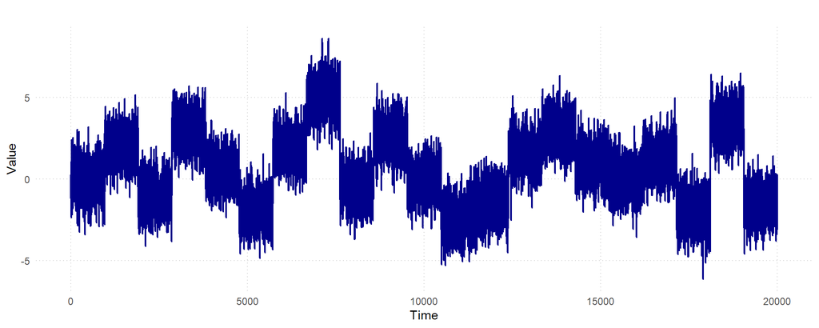

## 3.1 Run SCAN Change-Point Detection

The `window_sizes` argument controls the local scales used by the scan. The window sizes should be smaller than the spacing between nearby change points, while still being large enough to estimate the local distributions on each side of a candidate split.

```r
fit_mean <- scan_cpd(
  x_mean,
  window_sizes = c(100, 164, 227, 291, 355, 418, 482, 546, 609, 673, 737),
  n_boot = 400,
  random_state = 1234,
  change_type = "mean",
  n_jobs = 1
)

fit_mean
```

```
#> scanr change-point result
#> observations: 20000
#> change points: 952, 1905, 2858, 3809, 4760, 5715, 6668, 7620, 8573, 9525, 10478, 11410, 12380, 13338, 14288, 15230, 16177, 17145, 18098, 19050
```

> **Remark on bootstrap calibration**

> The adaptive threshold for declaring a change point is derived through a **tapered block bootstrap** across the combined windows. Increasing the number of bootstrap samples (`n_boot`) produces a more accurate null distribution at the cost of longer computation time; a value of 400–1,000 is typically sufficient. The method supports parallel processing via [Rust’s](https://www.rust-lang.org/) **Rayon** library for computational efficiency.

The estimated change points can be extracted directly from the fitted object.

```r
fit_mean$change_points
```

```
#>  [1]   952  1905  2858  3809  4760  5715  6668  7620  8573  9525 10478 11410
#> [13] 12380 13338 14288 15230 16177 17145 18098 19050
```

## 3.2 Evaluate Detection Accuracy

For simulated data, estimated change points can be compared with the known truth. The `tolerance` argument controls how close an estimated change point must be to a true change point to count as a match.

```r
cpd_metrics(
  true_cps = change_points,
  estimated_cps = fit_mean$change_points,
  n = length(x_mean),
  tolerance = 20
)
```

```
#> $matches
#>     true estimated distance
#> 1    952       952        0
#> 2   1905      1905        0
#> 3   2858      2858        0
#> 4   5715      5715        0
#> 5   6668      6668        0
#> 6   7620      7620        0
#> 7   8573      8573        0
#> 8   9525      9525        0
#> 9  10478     10478        0
#> 10 14288     14288        0
#> 11 17145     17145        0
#> 12 18098     18098        0
#> 13 19050     19050        0
```

[output cut: 19 more lines]

## 3.3 Visualize the Result

The package includes visual helpers for inspecting detected change points, window-level votes, and the overall vote scree.

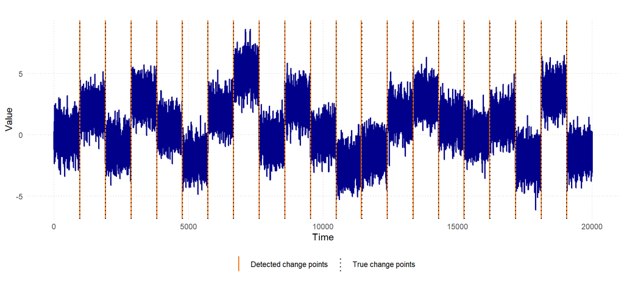

```r
vis_change_points(
  x_mean,
  fit_mean,
  true_change_points = change_points,
  x_label = "Time",
  y_label = "Value"
)
```

## 3.4 Tune the Voting Threshold

The ensemble vote threshold, `vote_threshold`, controls how much agreement is required across window sizes before a candidate is retained. The default value is 0.5, meaning that a candidate must be supported by at least half of the available window-level votes.

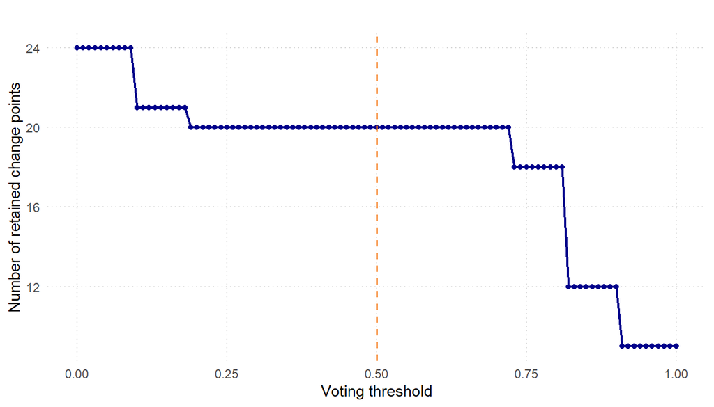

```r
vis_vote_scree(fit_mean)
```

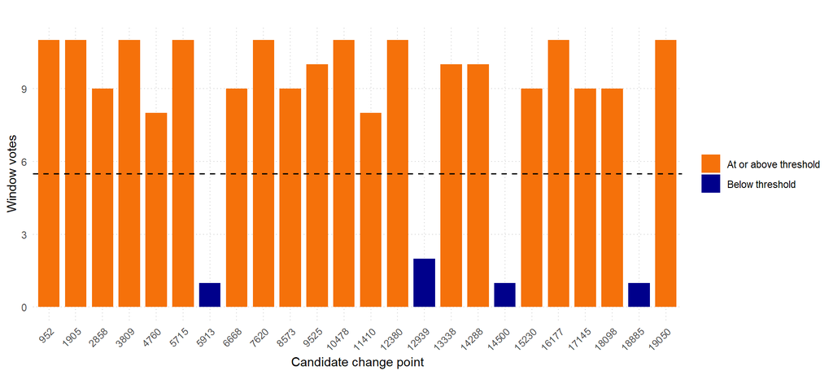

```r
vis_window_votes(fit_mean)
```

# 4 Example 2 - Changes in Distribution

The next example uses segments from different distribution families, including normal, exponential, Poisson, gamma, uniform, Student’s t, lognormal, beta, Weibull, and chi-square distributions. Each segment is standardized before being rescaled, so the signal is not only a simple shift in the mean. This creates a more challenging distributional change-point problem.

```r
set.seed(1234)

n <- 20000

change_points <- c(952, 1905, 2858, 3810, 4763, 5715, 6668, 7620, 8573, 9525, 10478, 11430, 12383, 13335, 14288, 15240, 16193, 17145, 18098, 19050)

segment_starts <- c(1, change_points + 1)
segment_ends <- c(change_points, n)

families <- c("normal", "exponential", "poisson", "t", "gamma", "uniform", "lognormal", "weibull", "chisq", "beta", "normal", "poisson", "exponential", "uniform", "gamma", "t", "lognormal", "beta", "weibull", "chisq", "normal")

scale_factors <- c(0.7, 1.4, 0.6, 1.8, 0.75, 2.5, 0.65, 3.0, 0.7, 2.6, 0.6, 1.7, 0.65, 2.9, 0.7, 2.8, 0.6, 2.6, 0.65, 3.0, 0.7)

simulate_base <- function(m, family) {
  z <- switch(family, normal = rnorm(m, mean = 0, sd = 1), exponential = rexp(m, rate = 1), poisson = rpois(m, lambda = 2), gamma = rgamma(m, shape = 2, rate = 1), uniform = runif(m, min = -sqrt(3), max = sqrt(3)), t = rt(m, df = 3), lognormal = rlnorm(m, meanlog = 0, sdlog = 0.7), beta = rbeta(m, shape1 = 2, shape2 = 5), weibull = rweibull(m, shape = 1.5, scale = 1), chisq = rchisq(m, df = 5))
  as.numeric((z - mean(z)) / sd(z))
}

x_dist <- numeric(n)

for (j in seq_along(families)) {
  segment_index <- segment_starts[j]:segment_ends[j]
  x_dist[segment_index] <-scale_factors[j] * simulate_base(length(segment_index), families[j])
}

change_points
```

```
#>  [1]   952  1905  2858  3810  4763  5715  6668  7620  8573  9525 10478 11430
#> [13] 12383 13335 14288 15240 16193 17145 18098 19050
```

The simulated series contains changes in distributional shape and scale.

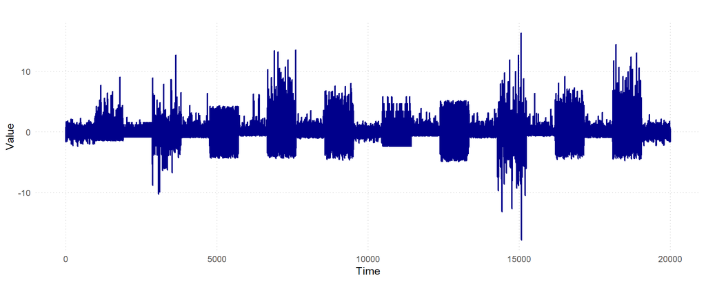

## 4.1 Run SCAN Change-Point Detection

For distributional changes, set `change_type = "distribution"`. This uses the distribution-sensitive local statistic rather than a mean-only statistic.

```r
fit_dist <- scan_cpd(
  x_dist,
  window_sizes = c(100, 145, 191, 236, 282, 327, 373, 418, 464, 509, 555, 600, 646, 691, 737),
  n_boot = 1000,
  random_state = 1234,
  change_type = "distribution",
  vote_threshold = 0.5,
  n_jobs = 1
)
```

The set of estimated change points is:

```r
fit_dist$change_points
```

```
#>  [1]   954  1902  2860  3809  4764  5709  6669  7611  8573  9522 10478 11430
#> [13] 12383 13335 14289 15240 16195 17145 18100 19048
```

## 4.2 Evaluate Detection Accuracy

```r
cpd_metrics(
  true_cps = change_points,
  estimated_cps = fit_dist$change_points,
  n = length(x_dist),
  tolerance = 20
)
```

```
#> $matches
#>     true estimated distance
#> 1   8573      8573        0
#> 2  10478     10478        0
#> 3  11430     11430        0
#> 4  12383     12383        0
#> 5  13335     13335        0
#> 6  15240     15240        0
#> 7  17145     17145        0
#> 8   3810      3809        1
#> 9   4763      4764        1
#> 10  6668      6669        1
#> 11 14288     14289        1
#> 12   952       954        2
#> 13  2858      2860        2
```

[output cut: 19 more lines]

## 4.3 Visualize the Result

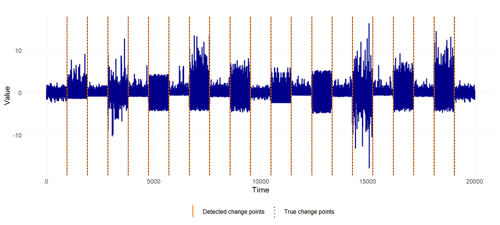

```r
vis_change_points(
  x_dist,
  fit_dist,
  true_change_points = change_points,
  x_label = "Time",
  y_label = "Value"
)
```

# 5 SWAL Statistic for Single Change-Point Detection

The SCAN procedure above combines local evidence across many windows. The package also exposes lower-level localization tools for a single region that is believed to contain one change point.

```r
set.seed(1234)

true_single_cp <- 150
mean_region <- c(
  rnorm(true_single_cp, mean = 0, sd = 1),
  rnorm(true_single_cp, mean = 2, sd = 1)
)

c(
  truth = true_single_cp,
  cusum = ts_cusum(mean_region),
  swal_distribution = swal_statistic(mean_region, change_type = "distribution")
)
```

```
#>             truth             cusum swal_distribution
#>               150               150               150
```

The distributional version is more general. It can localize changes where the mean is approximately unchanged but other aspects of the distribution, such as variance, change sharply. In the example below, both segments have mean zero, but the second segment has a much larger standard deviation.

```r
set.seed(1234)

var_region <- c(
  rnorm(true_single_cp, mean = 0, sd = 0.5),
  rnorm(true_single_cp, mean = 0, sd = 2)
)

c(
  truth = true_single_cp,
  cusum = ts_cusum(var_region),
  swal_distribution = swal_statistic(var_region, change_type = "distribution")
)
```

```
#>             truth             cusum swal_distribution
#>               150               164               152
```

The `ts_wasserstein()` function returns both the estimated split and the full sequence of split statistics. The plotting helper `vis_swal_curve()` displays that localization curve, making it easier to inspect where the statistic is maximized.

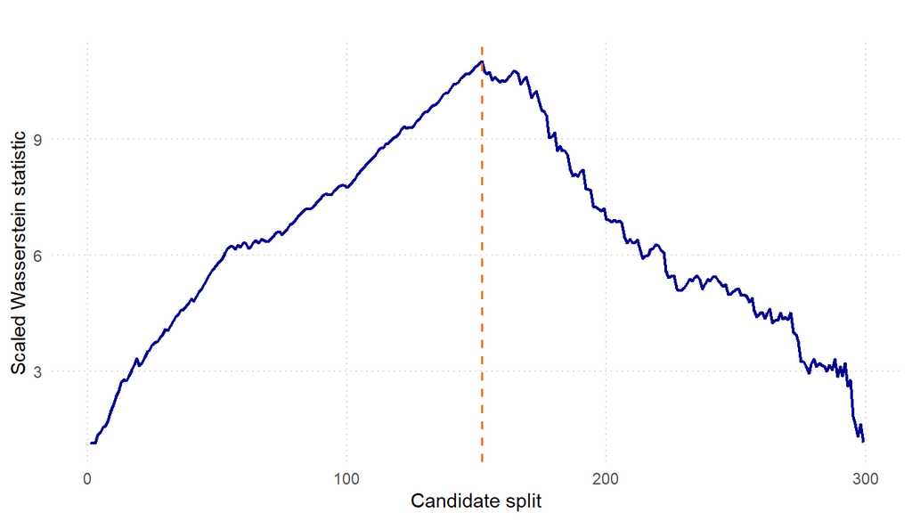

```r
vis_swal_curve(
  var_region,
  start = 1,
  end = length(var_region),
  x_label = "Candidate split",
  y_label = "Scaled Wasserstein statistic",
  title = ""
)
```